# Testing the Equality of Regression Coefficients

Author: Rick Dean

Article date: 2021-02-17

Abstract

The following notes and R scripts were inspired by an article titled [Testing the Equality of Regression Coefficients](https://shouldbewriting.netlify.app/posts/2021-02-16-testing-coefficients-equality/) by Mattan S. Ben-Shachar. The author compares four methods with an example data set.

```r
library(knitr)
library(kableExtra)
library(data.table)
library(effectsize)
library(RregressPkg)
library(RplotterPkg)
library(car)
library(ggplot2)
```

## The data set

### Access the data

Source of the data is `effectsize::hardlyworking` where the response is a *worker’s salary* (**salary**) and predictors *number of extra hours* (**xtra_hours**) and *number of compliments* (**n_comps**).

```r
data("hardlyworking", package = "effectsize")
head(hardlyworking)
```

```
##     salary xtra_hours n_comps age seniority
## 1 19744.65   4.161812       1  32         3
## 2 11301.95   1.621868       0  34         3
## 3 20635.62   1.190859       3  33         5
## 4 23047.16   7.190997       1  35         3
## 5 27342.15  11.261399       0  33         4
## 6 25656.63   3.633346       2  30         5
```

### Plot the response with the predictors

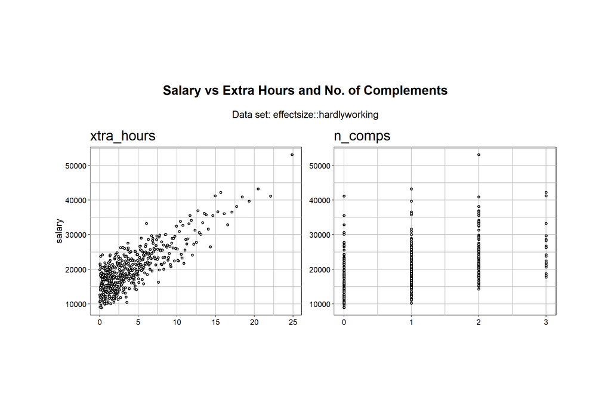

```r
RplotterPkg::multi_scatter_plot(
  df = hardlyworking,
  variables = c("xtra_hours", "n_comps"),
  aes_y = "salary",
  title = "Salary vs Extra Hours and No. of Complements",
  subtitle = "Data set: effectsize::hardlyworking",
  rot_y_tic_label = T,
  col_width = 5
)
```

### Standardize the data

```r
hardlyworking_dt <- data.table::setDT(hardlyworking)
hardlyworking_dt[, `:=`(salary_z = scale(salary), xtra_hours_z = scale(xtra_hours), n_comps_z = scale(n_comps))]
```

## Method 1: As model comparisons

### Compute the OLS estimates for the first lm model `salary_z ~ xtra_hours_z + n_comps_z`

```r
model_1_lst <- RregressPkg::ols_calc(df = hardlyworking_dt, formula_obj = salary_z ~ xtra_hours_z + n_comps_z)
RplotterPkg::create_table(x = model_1_lst$coef_df, caption = "Model 1: salary_z ~ xtra_hours_z + n_comps_z")
```

Model 1: salary_z ~ xtra_hours_z + n_comps_z

| Coef | Value | SE | t_value | p_Value |
| --- | --- | --- | --- | --- |
| (Intercept) | -1.288032e-16 | 0.01738438 | -7.409133e-15 | 1.000000e+00 |
| xtra_hours_z | 8.106567e-01 | 0.01741455 | 4.655054e+01 | 3.871361e-183 |
| n_comps_z | 4.089754e-01 | 0.01741455 | 2.348470e+01 | 1.481052e-82 |

### Compute the OLS estimates for the second lm model `salary_z ~ I(xtra_hours_z + n_comps_z)`

```r
model_2_lst <- RregressPkg::ols_calc(df = hardlyworking_dt, formula_obj = salary_z ~ I(xtra_hours_z + n_comps_z))
RplotterPkg::create_table(x = model_2_lst$coef_df, caption = "Model 2: salary_z ~ I(xtra_hours_z + n_comps_z)")
```

Model 2: salary_z ~ I(xtra_hours_z + n_comps_z)

| Coef | Value | SE | t_value | p_Value |
| --- | --- | --- | --- | --- |
| (Intercept) | -1.147086e-16 | 0.02138706 | -5.363457e-15 | 1.000000e+00 |
| I(xtra_hours_z + n_comps_z) | 6.098161e-01 | 0.01485648 | 4.104713e+01 | 9.018998e-162 |

### Compare the models via ANOVA

Model 1 ANOVA

```r
RplotterPkg::create_table(x = model_1_lst$anova_df, caption = "Model 1: salary_z ~ xtra_hours_z + n_comps_z")
```

Model 1: salary_z ~ xtra_hours_z + n_comps_z

| Source | DF | SS | MS |
| --- | --- | --- | --- |
| Regression | 3 | 424.05024 | 141.3500787 |
| Residual Error | 496 | 74.94976 | 0.1511084 |
| Total | 499 | 499.00000 | NA |

Model 2 ANOVA

```r
RplotterPkg::create_table(x = model_2_lst$anova_df, caption = "Model 2: salary_z ~ I(xtra_hours_z + n_comps_z)")
```

Model 2: salary_z ~ I(xtra_hours_z + n_comps_z)

| Source | DF | SS | MS |
| --- | --- | --- | --- |
| Regression | 2 | 385.3345 | 192.6672490 |
| Residual Error | 497 | 113.6655 | 0.2287032 |
| Total | 499 | 499.0000 | NA |

Using `stats::anova()`:

```r
 model_1_lm <- lm(salary_z ~ xtra_hours_z + n_comps_z, data = hardlyworking_dt)
 model_2_lm <- lm(salary_z ~ I(xtra_hours_z + n_comps_z), data=hardlyworking_dt)
 stats::anova(model_1_lm,model_2_lm)
```

```
## Analysis of Variance Table
##
## Model 1: salary_z ~ xtra_hours_z + n_comps_z
## Model 2: salary_z ~ I(xtra_hours_z + n_comps_z)
##   Res.Df    RSS Df Sum of Sq      F    Pr(>F)
## 1    497  74.95
## 2    498 113.67 -1   -38.716 256.73 < 2.2e-16 ***
## ---
## Signif. codes:  0 '***' 0.001 '**' 0.01 '*' 0.05 '.' 0.1 ' ' 1
```

Note: It appears that model 1 is preferred (with a lower SS Residual Error) and its predictors are showing that $\hat{\beta}_{XtraHours}$ > $\hat{\beta}_{Compliments}$

## Method 2: Paternoster et al (1998)

Compute the $t$-test to compare the coefficients according to [Paternoster et al (1998)](https://citeseerx.ist.psu.edu/viewdoc/download?doi=10.1.1.1025.8565&rep=rep1&type=pdf). From the first model results that separates the two coefficients (*model_1_lst*): 1. The model’s coefficient differences:

```r
b_x_hours <- model_1_lst$coef_df$Value[[2]]
b_n_comp <- model_1_lst$coef_df$Value[[3]]
diff_coef =b_x_hours - b_n_comp
```

diff_coef = 0.4016813

2. The model’s standard errors of the coefficients:

```r
sd_x_hours <- model_1_lst$coef_df$SE[[2]]
sd_n_comp <- model_1_lst$coef_df$SE[[3]]
```

sd_x_hours = 0.0174146

sd_n_comp = 0.0174146

```r
Z = diff_coef / sqrt(sd_x_hours^2 + sd_n_comp^2)
```

Z = 16.3100127

4. The variance for the difference between two coefficients:
   $$Var(\hat\beta_{1} - \hat\beta_{2}) = Var(\hat\beta_{1}) + Var(\hat\beta_{2}) - 2*Cov(\hat\beta_{1},\hat{\beta_{2}})$$

```r
var_diff <- sd_n_comp^2 + sd_x_hours^2 - 2 * model_1_lst$var_cov[2,3]

se_diff <- sqrt(var_diff)
```

var_diff = 6.2974419^{-4}

se_diff = 0.0250947

5. The $t$-statistic with n-p degrees of freedom (n = 500, p = 2 var + 1 intercept) = 497:
   $$t_{diff} = \frac{b_{1} - b_{2}}{SE_{diff}}$$

```r
t_diff = diff_coef/se_diff
```

t_diff = 16.0066141

Z = 16.3100127

```r
car::linearHypothesis(model_1_lm, c("xtra_hours_z - n_comps_z"))
```

```
## Linear hypothesis test
##
## Hypothesis:
## xtra_hours_z - n_comps_z = 0
##
## Model 1: restricted model
## Model 2: salary_z ~ xtra_hours_z + n_comps_z
##
##   Res.Df    RSS Df Sum of Sq      F    Pr(>F)
## 1    498 113.67
## 2    497  74.95  1    38.716 256.73 < 2.2e-16 ***
## ---
## Signif. codes:  0 '***' 0.001 '**' 0.01 '*' 0.05 '.' 0.1 ' ' 1
```